# Top 995 Global Youtube channel

Chinnagrit Juntarasook

2023-09-07

## Dataset

This project explores the [Global YouTube Statistics](https://www.kaggle.com/datasets/nelgiriyewithana/global-youtube-statistics-2023) 2023 datasets by Nidula Elgiriyewithana from kaggle, which includes top 996 channel ranked by number of subscribers. This proejct uses tidyverse, sqldf and scales packages.

```r
#show a few columns and ten rows of the dataset
head(Global_Youtube_Statistics, n = 5)
```

```
##   rank                   Youtuber subscribers  video.views         category
## 1    1                   T-Series   245000000 228000000000            Music
## 2    2             YouTube Movies   170000000            0 Film & Animation
## 3    3                    MrBeast   166000000  28368841870    Entertainment
## 4    4 Cocomelon - Nursery Rhymes   162000000 164000000000        Education
## 5    5                  SET India   159000000 148000000000            Shows
##                        Title uploads       Country Abbreviation  channel_type
## 1                   T-Series   20082         India           IN         Music
## 2              youtubemovies       1 United States           US         Games
## 3                    MrBeast     741 United States           US Entertainment
## 4 Cocomelon - Nursery Rhymes     966 United States           US     Education
## 5                  SET India  116536         India           IN Entertainment
##   video_views_rank country_rank channel_type_rank
## 1                1            1                 1
## 2          4055159         7670              7423
```

[output cut: 33 more lines]

## Cleaning data

#### Standardise header names

```r
#Some of the headers start with a capital letter while some don't
colnames(Global_Youtube_Statistics)[1:10]
```

```
##  [1] "rank"         "Youtuber"     "subscribers"  "video.views"  "category"
##  [6] "Title"        "uploads"      "Country"      "Abbreviation" "channel_type"
```

```r
#change header names so they follow the same formats
colnames(Global_Youtube_Statistics) <- tolower(colnames(Global_Youtube_Statistics))
colnames(Global_Youtube_Statistics)[1:10]
```

```
##  [1] "rank"         "youtuber"     "subscribers"  "video.views"  "category"
##  [6] "title"        "uploads"      "country"      "abbreviation" "channel_type"
```

#### Remove duplications

```r
#check if there are any duplicates
duplicates <- duplicated(Global_Youtube_Statistics)

num_duplicates <- sum(duplicates)

print(num_duplicates)
```

```
## [1] 0
```

```
  There is no duplicate rows in datasets
```

#### Merge created year, month and data into a single column as data format

```r
Global_Youtube_Statistics$creation_date <- as.Date(
  paste(
    Global_Youtube_Statistics$created_year,
    Global_Youtube_Statistics$created_month,
    Global_Youtube_Statistics$created_date,
    sep = "-"
  ),
  format = "%Y-%b-%d"
)
```

#### Numbers are displayed in scientific notation (2.28e+11)

```r
# Prevent R from using scientific notation for large numbers
options(scipen = 999)
```

### Cleaned dataset preview

```r
head(Global_Youtube_Statistics, n = 5)
```

```
##   rank                   youtuber subscribers  video.views         category
## 1    1                   T-Series   245000000 228000000000            Music
## 2    2             YouTube Movies   170000000            0 Film & Animation
## 3    3                    MrBeast   166000000  28368841870    Entertainment
## 4    4 Cocomelon - Nursery Rhymes   162000000 164000000000        Education
## 5    5                  SET India   159000000 148000000000            Shows
##                        title uploads       country abbreviation  channel_type
## 1                   T-Series   20082         India           IN         Music
## 2              youtubemovies       1 United States           US         Games
## 3                    MrBeast     741 United States           US Entertainment
## 4 Cocomelon - Nursery Rhymes     966 United States           US     Education
## 5                  SET India  116536         India           IN Entertainment
##   video_views_rank country_rank channel_type_rank
## 1                1            1                 1
## 2          4055159         7670              7423
```

[output cut: 33 more lines]

## Data exploration

##### Youtube creators per countires

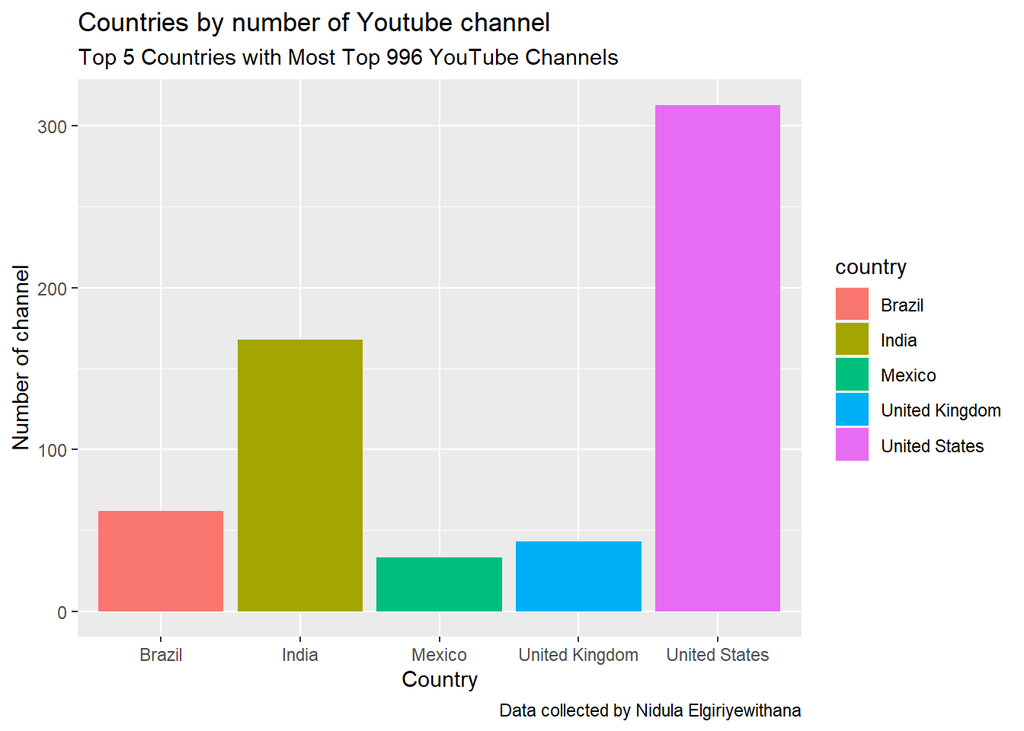

```r
# Top 10 countires, excluding channel that have 'nan' in country column)
top5_countries <- sqldf("SELECT count(*) as number, country
           FROM Global_Youtube_Statistics
           WHERE country <> 'nan'
           GROUP by country
           ORDER BY number DESC
           LIMIT 5")
#plot
ggplot(data = top5_countries) +
  geom_bar(mapping = aes(x = country, y = number, fill = country),stat = "identity") +
  labs(title = "Countries by number of Youtube channel",
       subtitle = "Top 5 Countries with Most Top 996 YouTube Channels",
       caption = "Data collected by Nidula Elgiriyewithana",
       x = "Country",
       y = "Number of channel")
```

Based on the bar graph, The United States has the most YouTube channels who are ranking in the top 996 worldwide, followed by India and Brazil

```r
#Find the average subscribers of each country
Global_Youtube_Statistics %>%
  group_by(country) %>%
  summarise(mean_subscribers = mean(subscribers), highest_subscribers = max(subscribers), lowest_subscribers = min(subscribers)) %>%
  arrange(-mean_subscribers)
```

```
## # A tibble: 50 × 4
##    country     mean_subscribers highest_subscribers lowest_subscribers
##    <chr>                  <dbl>               <int>              <int>
##  1 Cuba               46300000             46300000           46300000
##  2 El Salvador        46100000             46100000           46100000
##  3 Barbados           41900000             41900000           41900000
##  4 Japan              37820000            111000000           14900000
##  5 Venezuela          31200000             31200000           31200000
##  6 Kuwait             30500000             30500000           30500000
##  7 Chile              29066667.            48100000           17600000
##  8 South Korea        28335294.            89800000           12600000
##  9 Pakistan           25900000             44600000           12500000
## 10 India              25658333.           245000000           12300000
## # ℹ 40 more rows
```

The country with the highest average number of subscribers is Cuba, followed by El Salvador and Barbados. However, all these countries have only one channel, as the subscriber number of the highest-subscribed channel is the same as the country’s average.

```r
#excluding countries with only one channel to reduce biases
Global_Youtube_Statistics %>%
  group_by(country) %>%
  summarise(mean_subscribers = mean(subscribers), highest_subscribers = max(subscribers), lowest_subscribers = min(subscribers)) %>%
  arrange(-mean_subscribers) %>%
  filter(mean_subscribers != highest_subscribers)
```

```
## # A tibble: 34 × 4
##    country     mean_subscribers highest_subscribers lowest_subscribers
##    <chr>                  <dbl>               <int>              <int>
##  1 Japan              37820000            111000000           14900000
##  2 Chile              29066667.            48100000           17600000
##  3 South Korea        28335294.            89800000           12600000
##  4 Pakistan           25900000             44600000           12500000
##  5 India              25658333.           245000000           12300000
##  6 Russia             25450000            106000000           13200000
##  7 Argentina          25269231.            58400000           15100000
##  8 Canada             24260000             71600000           12400000
##  9 Colombia           24045455.            43500000           12700000
## 10 nan                23952459.           119000000           12400000
## # ℹ 24 more rows
```

Now, the countries with the highest average subscriber numbers are Japan, followed by Chile and South Korea.

#### Youtube channels per categories

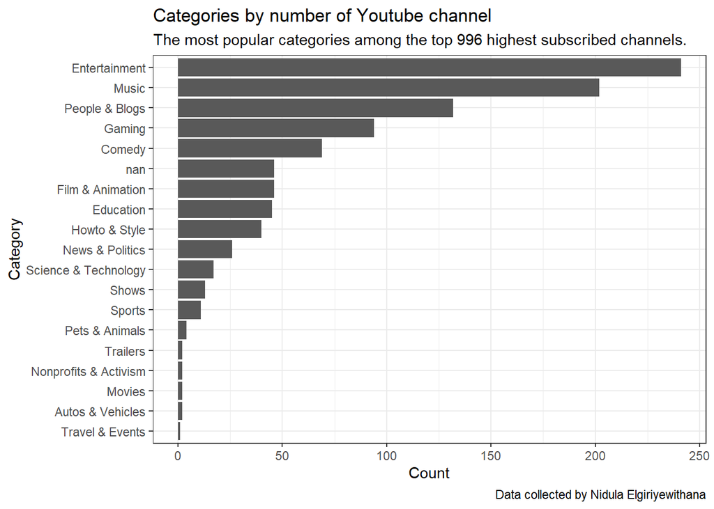

```r
# Calculate the count of each category
category_count <- Global_Youtube_Statistics %>%
  group_by(category) %>%
  summarise(count = n())

ggplot(data = category_count) +
  geom_bar(mapping = aes(x = reorder(category, count), y = count ), stat = "identity") +
  coord_flip() +
  theme_bw()+
  labs(title = "Categories by number of Youtube channel",
       subtitle = "The most popular categories among the top 996 highest subscribed channels.",
       caption = "Data collected by Nidula Elgiriyewithana",
       x = "Category",
       y = "Count")
```

Based on the analysis of the top 996 highest subscribed YouTube channels, it is evident that the most prevalent category among these channels is entertainment fllowed by music and People & Blog. This information underscores the dominance of entertainment-related content on the platform

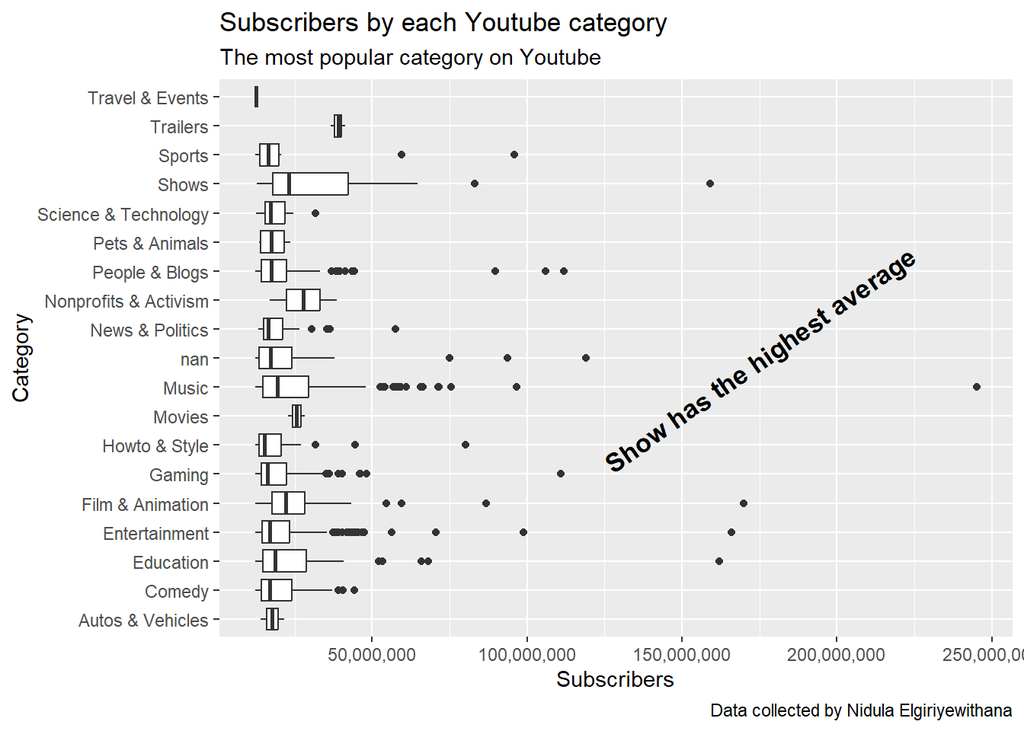

```r
ggplot(data = Global_Youtube_Statistics) +
  geom_boxplot(mapping = aes(x = subscribers, y = category)) +
  scale_x_continuous(labels = comma) +
  labs(title = "Subscribers by each Youtube category",
       subtitle = "The most popular category on Youtube",
       caption = "Data collected by Nidula Elgiriyewithana",
       x = "Subscribers",
       y = "Category") +
  annotate("text", x=175000000, y=10, label="Show has the highest average",
           fontface="bold",size=4.5, angle=35)
```

```r
Global_Youtube_Statistics %>%
  group_by(category) %>%
  summarise(mean_subscribers = mean(subscribers), highest_subscribers = max(subscribers), lowest_subscribers = min(subscribers)) %>%
  arrange(-mean_subscribers)
```

```
## # A tibble: 19 × 4
##    category              mean_subscribers highest_subscribers lowest_subscribers
##    <chr>                            <dbl>               <int>              <int>
##  1 Shows                        41615385.           159000000           12900000
##  2 Trailers                     39000000             41400000           36600000
##  3 Film & Animation             28584783.           170000000           12400000
##  4 Nonprofits & Activism        27750000             38600000           16900000
##  5 Sports                       27109091.            96000000           12300000
##  6 Education                    26542222.           162000000           12400000
##  7 Music                        25717822.           245000000           12400000
##  8 Movies                       25650000             28400000           22900000
##  9 nan                          23997826.           119000000           12300000
## 10 Entertainment                21403320.           166000000           12400000
## 11 People & Blogs               21056061.           112000000           12300000
## 12 Gaming                       20852128.           111000000           12300000
## 13 News & Politics              20630769.            57600000           13400000
## 14 Comedy                       20123188.            44200000           12300000
## 15 Howto & Style                19390000             80100000           12400000
## 16 Science & Technology         18617647.            31700000           12500000
## 17 Pets & Animals               18100000             23700000           13600000
## 18 Autos & Vehicles             17850000             21600000           14100000
## 19 Travel & Events              12500000             12500000           12500000
```

“Shows” have the highest mean number of subscribers, while “Music” boasts the highest single-channel subscriber count. This indicates that, on average, “Shows” is the most popular category, while the music category has the most successful channel.

##### Number of Subscribers / Number of Views

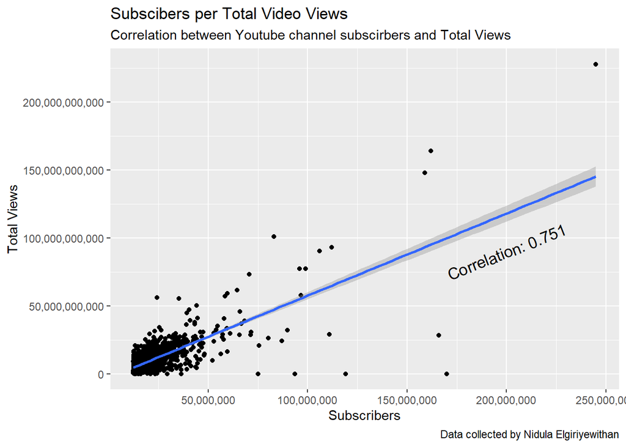

```r
ggplot(data = Global_Youtube_Statistics) +
  geom_point(mapping = aes(x = subscribers, y = video.views)) +
  geom_smooth(mapping = aes(x = subscribers, y = video.views), method = "lm") +
  scale_x_continuous(labels = comma) +
  scale_y_continuous(labels = comma) +
  labs(title = "Subscibers per Total Video Views",
       subtitle = "Correlation between Youtube channel subscirbers and Total Views",
       caption = "Data collected by Nidula Elgiriyewithan",
       x = "Subscribers",
       y =  "Total Views") +
  annotate("text", x = 200000000 ,y = 90000000000 ,label = paste("Correlation:", round(cor(Global_Youtube_Statistics$subscribers, Global_Youtube_Statistics$video.views), 4)), size = 4.5, angle = 21.5)
```

[output not shown]